# Feature Selection Stability Analysis

Harshini Chintala

2026-09-04

## 0.1 Notebook roadmap

**Purpose:** This notebook is one reproducible component of the CRC microbiome classification pipeline.

**Execution order** 1. Load the project environment and fixed random seed (`1910`). 2. Load only the validated project artifacts required for this analysis. 3. Perform the analysis exactly as documented below. 4. Generate tables/figures and save machine-readable outputs. 5. Record the session information used for the run.

**Output contract:** generated tables, figures, model objects, audit files, and session information are written under `02 Classical ML/results/`. The notebook itself renders to HTML with a floating table of contents, so the sections can be navigated from the left-hand panel in the knitted document.

**Reproducibility rule:** this repository preserves the validated analysis logic and project-wide seed. Environment restoration is handled by `renv.lock` for R and `requirements.txt` for Python. The notebooks do not silently install unpinned packages during knitting.

### 0.1.1 Reproducibility constants

- Project seed: **1910**
- Discovery cohort: **ZellerG_2014**
- Primary task: **Healthy vs CRC; adenoma excluded**
- Frozen discovery split: **92 training / 22 held-out test samples**
- Primary feature panel: **20 Boruta-selected features**
- External cohorts: **FengQ_2015** and **VogtmannE_2016**

# 1 1. Packages and Project Paths

```r
# ==========================================================
# PACKAGES
# ==========================================================

library(curatedMetagenomicData)
library(TreeSummarizedExperiment)
library(SummarizedExperiment)
library(caret)
library(Boruta)
library(dplyr)
library(ggplot2)

# ==========================================================
# REPRODUCIBILITY
# ==========================================================

set.seed(1910)

# ==========================================================
# PROJECT PATHS
# ==========================================================

project_dir <- classical_dir

models_dir <- file.path(
  project_dir,
  "models"
)

results_dir <- file.path(
  project_dir,
  "results"
)

figures_dir <- file.path(
  project_dir,
  "figures"
)

stability_dir <- file.path(
  results_dir,
  "feature_selection_stability"
)

dir.create(
  stability_dir,
  recursive = TRUE,
  showWarnings = FALSE
)

dir.create(
  figures_dir,
  recursive = TRUE,
  showWarnings = FALSE
)

cat("Project directory:\n", project_dir, "\n")
## Project directory:
##  C:/CRC/CRC_Quantum_Microbiome_Githb/CRC_Quantum_Microbiome_GitHub_RMD/02 Classical ML
cat("Models directory:\n", models_dir, "\n")
## Models directory:
##  C:/CRC/CRC_Quantum_Microbiome_Githb/CRC_Quantum_Microbiome_GitHub_RMD/02 Classical ML/models
cat("Results directory:\n", results_dir, "\n")
## Results directory:
##  C:/CRC/CRC_Quantum_Microbiome_Githb/CRC_Quantum_Microbiome_GitHub_RMD/02 Classical ML/results
cat("Stability output directory:\n", stability_dir, "\n")
## Stability output directory:
##  C:/CRC/CRC_Quantum_Microbiome_Githb/CRC_Quantum_Microbiome_GitHub_RMD/02 Classical ML/results/feature_selection_stability
```

# 2 2. Load the Exact Discovery Training Set

```r
# ==========================================================
# LOAD SHARED TRAIN-TEST SPLIT
# ==========================================================

train_index_path <- file.path(
  models_dir,
  "BinaryClass_Train_Index.rds"
)

if (!file.exists(train_index_path)) {
  stop(
    "Shared train-test index not found:\n",
    train_index_path
  )
}

train_index <- readRDS(
  train_index_path
)

# ==========================================================
# LOAD ZELLER DATASET
# ==========================================================

zeller <- curatedMetagenomicData(
  "ZellerG_2014.relative_abundance",
  dryrun = FALSE
)[[1]]

abundance <- assay(zeller)

# Original:
# rows = microbial features
# columns = samples
#
# Transpose to:
# rows = samples
# columns = microbial features

abundance_df <- as.data.frame(
  t(abundance),
  check.names = FALSE
)

# ==========================================================
# BUILD BINARY OUTCOME
# ==========================================================

metadata <- as.data.frame(
  colData(zeller)
)

disease_raw <- metadata$disease

disease <- factor(
  ifelse(
    disease_raw == "control",
    "healthy",
    as.character(disease_raw)
  ),
  levels = c("healthy", "CRC")
)

# Keep only Healthy and CRC
binary_keep <- disease %in% c(
  "healthy",
  "CRC"
)

binary_data <- abundance_df[
  binary_keep,
  ,
  drop = FALSE
]

disease_binary <- droplevels(
  disease[binary_keep]
)

# ==========================================================
# VERIFY SHARED TRAINING SET
# ==========================================================

if (max(train_index) > nrow(binary_data)) {
  stop(
    "Shared train index contains row numbers outside the binary dataset."
  )
}

X_train_raw <- binary_data[
  train_index,
  ,
  drop = FALSE
]

y_train <- disease_binary[
  train_index
]

if (nrow(X_train_raw) != 92) {
  stop(
    "Expected 92 training samples but found ",
    nrow(X_train_raw)
  )
}

cat(
  "Training samples:",
  nrow(X_train_raw),
  "\n"
)
## Training samples: 92

cat(
  "Training features:",
  ncol(X_train_raw),
  "\n"
)
## Training features: 652

cat(
  "\nTraining class distribution:\n"
)
```

```
##
## Training class distribution:
```

```r
print(
  table(y_train)
)
## y_train
## healthy     CRC
##      49      43
```

# 3 3. Load the Original 20 Discovery Features

```r
# ==========================================================
# ORIGINAL DISCOVERY FEATURE SET
# ==========================================================

original_features_path <- file.path(
  results_dir,
  "Binary_Selected_20_Features.csv"
)

if (!file.exists(original_features_path)) {
  stop(
    "Original 20-feature file not found:\n",
    original_features_path
  )
}

original_features <- read.csv(
  original_features_path,
  stringsAsFactors = FALSE
)[[1]]

if (length(original_features) != 20) {
  stop(
    "Expected exactly 20 original features but found ",
    length(original_features)
  )
}

missing_original_features <- setdiff(
  original_features,
  colnames(X_train_raw)
)

if (length(missing_original_features) > 0) {
  stop(
    "Original discovery features missing from training data:\n",
    paste(
      missing_original_features,
      collapse = "\n"
    )
  )
}

cat(
  "Original discovery feature count:",
  length(original_features),
  "\n"
)
## Original discovery feature count: 20

print(
  original_features
)
```

```
##  [1] "k__Bacteria|p__Firmicutes|c__Clostridia|o__Clostridiales|f__Lachnospiraceae|g__Anaerostipes|s__Anaerostipes_hadrus"
##  [2] "k__Bacteria|p__Firmicutes|c__Clostridia|o__Clostridiales|f__Lachnospiraceae|g__Lachnospiraceae_unclassified|s__Eubacterium_rectale"
##  [3] "k__Bacteria|p__Firmicutes|c__Clostridia|o__Clostridiales|f__Eubacteriaceae|g__Eubacterium|s__Eubacterium_hallii"
##  [4] "k__Bacteria|p__Bacteroidetes|c__Bacteroidia|o__Bacteroidales|f__Bacteroidaceae|g__Bacteroides|s__Bacteroides_uniformis"
##  [5] "k__Bacteria|p__Firmicutes|c__Clostridia|o__Clostridiales|f__Ruminococcaceae|g__Ruminococcus|s__Ruminococcus_bicirculans"
##  [6] "k__Bacteria|p__Firmicutes|c__Clostridia|o__Clostridiales|f__Oscillospiraceae|g__Oscillibacter|s__Oscillibacter_sp_CAG_241"
##  [7] "k__Bacteria|p__Firmicutes|c__Clostridia|o__Clostridiales|f__Lachnospiraceae|g__Blautia|s__Blautia_wexlerae"
##  [8] "k__Bacteria|p__Firmicutes|c__Clostridia|o__Clostridiales|f__Ruminococcaceae|g__Ruthenibacterium|s__Ruthenibacterium_lactatiformans"
##  [9] "k__Bacteria|p__Proteobacteria|c__Deltaproteobacteria|o__Desulfovibrionales|f__Desulfovibrionaceae|g__Bilophila|s__Bilophila_wadsworthia"
## [10] "k__Bacteria|p__Firmicutes|c__Bacilli|o__Lactobacillales|f__Streptococcaceae|g__Streptococcus|s__Streptococcus_salivarius"
## [11] "k__Bacteria|p__Firmicutes|c__Clostridia|o__Clostridiales|f__Peptostreptococcaceae|g__Intestinibacter|s__Intestinibacter_bartlettii"
## [12] "k__Bacteria|p__Proteobacteria|c__Betaproteobacteria|o__Burkholderiales|f__Sutterellaceae|g__Turicimonas|s__Turicimonas_muris"
## [13] "k__Bacteria|p__Firmicutes|c__Tissierellia|o__Tissierellales|f__Peptoniphilaceae|g__Parvimonas|s__Parvimonas_micra"
## [14] "k__Bacteria|p__Firmicutes|c__Clostridia|o__Clostridiales|f__Ruminococcaceae|g__Flavonifractor|s__Flavonifractor_plautii"
## [15] "k__Bacteria|p__Firmicutes|c__Clostridia|o__Clostridiales|f__Clostridiaceae|g__Hungatella|s__Hungatella_hathewayi"
## [16] "k__Bacteria|p__Firmicutes|c__Negativicutes|o__Veillonellales|f__Veillonellaceae|g__Dialister|s__Dialister_pneumosintes"
## [17] "k__Bacteria|p__Firmicutes|c__Clostridia|o__Clostridiales|f__Peptostreptococcaceae|g__Peptostreptococcus|s__Peptostreptococcus_stomatis"
## [18] "k__Bacteria|p__Proteobacteria|c__Deltaproteobacteria|o__Desulfovibrionales|f__Desulfovibrionaceae|g__Desulfovibrio|s__Desulfovibrio_piger"
## [19] "k__Bacteria|p__Firmicutes|c__Clostridia|o__Clostridiales|f__Clostridiales_Family_XIII_Incertae_Sedis|g__Mogibacterium|s__Mogibacterium_timidum"
## [20] "k__Bacteria|p__Fusobacteria|c__Fusobacteriia|o__Fusobacteriales|f__Fusobacteriaceae|g__Fusobacterium|s__Fusobacterium_nucleatum"
```

# 4 4. One Pilot Subsample

```r
# ==========================================================
# PILOT STRATIFIED SUBSAMPLE
# ==========================================================

set.seed(1910)

healthy_idx <- which(
  y_train == "healthy"
)

crc_idx <- which(
  y_train == "CRC"
)

# 80% of each class, without replacement
n_healthy_sub <- floor(
  length(healthy_idx) * 0.80
)

n_crc_sub <- floor(
  length(crc_idx) * 0.80
)

pilot_healthy <- sample(
  healthy_idx,
  size = n_healthy_sub,
  replace = FALSE
)

pilot_crc <- sample(
  crc_idx,
  size = n_crc_sub,
  replace = FALSE
)

pilot_idx <- c(
  pilot_healthy,
  pilot_crc
)

X_pilot <- X_train_raw[
  pilot_idx,
  ,
  drop = FALSE
]

y_pilot <- y_train[
  pilot_idx
]

cat(
  "Pilot sample size:",
  nrow(X_pilot),
  "\n"
)
## Pilot sample size: 73

cat(
  "Pilot class distribution:\n"
)
## Pilot class distribution:

print(
  table(y_pilot)
)
## y_pilot
## healthy     CRC
##      39      34

# ==========================================================
# NZV FILTERING
# ==========================================================

pilot_nzv <- nearZeroVar(
  X_pilot
)

if (length(pilot_nzv) > 0) {

  X_pilot_nzv <- X_pilot[
    ,
    -pilot_nzv,
    drop = FALSE
  ]

} else {

  X_pilot_nzv <- X_pilot

}

cat(
  "Features after NZV:",
  ncol(X_pilot_nzv),
  "\n"
)
## Features after NZV: 273

# ==========================================================
# BORUTA
# ==========================================================

pilot_boruta_data <- data.frame(
  Disease = y_pilot,
  X_pilot_nzv,
  check.names = FALSE
)

pilot_boruta <- Boruta(
  Disease ~ .,
  data = pilot_boruta_data,
  doTrace = 0
)

pilot_boruta_final <- TentativeRoughFix(
  pilot_boruta
)

pilot_selected <- getSelectedAttributes(
  pilot_boruta_final,
  withTentative = FALSE
)

cat(
  "Features selected in pilot:",
  length(pilot_selected),
  "\n"
)
## Features selected in pilot: 12

pilot_overlap <- intersect(
  original_features,
  pilot_selected
)

cat(
  "Original 20 recovered in pilot:",
  length(pilot_overlap),
  "/ 20\n"
)
## Original 20 recovered in pilot: 11 / 20
```

# 5 5. 200-Iteration Feature-Selection Stability Analysis

```r
# ==========================================================
# FEATURE-SELECTION STABILITY ANALYSIS
# 200 STRATIFIED SUBSAMPLING ITERATIONS
# ==========================================================

set.seed(1910)

n_iterations <- 200

# ----------------------------------------------------------
# Storage
# ----------------------------------------------------------

selected_features_list <- vector(
  "list",
  n_iterations
)

n_features_selected <- integer(
  n_iterations
)

n_original_recovered <- integer(
  n_iterations
)

iteration_warning_count <- integer(
  n_iterations
)

iteration_warning_messages <- vector(
  "list",
  n_iterations
)

# ----------------------------------------------------------
# Fixed class indices from the original training set
# ----------------------------------------------------------

healthy_idx <- which(
  y_train == "healthy"
)

crc_idx <- which(
  y_train == "CRC"
)

# ----------------------------------------------------------
# Start iterations
# ----------------------------------------------------------

for (i in seq_len(n_iterations)) {

  cat(
    "\n========================================\n",
    "Iteration:",
    i,
    "/",
    n_iterations,
    "\n",
    "========================================\n"
  )

  # --------------------------------------------------------
  # STRATIFIED SUBSAMPLING WITHOUT REPLACEMENT
  # --------------------------------------------------------

  n_healthy_sub <- floor(
    length(healthy_idx) * 0.80
  )

  n_crc_sub <- floor(
    length(crc_idx) * 0.80
  )

  sub_healthy <- sample(
    healthy_idx,
    size = n_healthy_sub,
    replace = FALSE
  )

  sub_crc <- sample(
    crc_idx,
    size = n_crc_sub,
    replace = FALSE
  )

  sub_idx <- c(
    sub_healthy,
    sub_crc
  )

  X_sub <- X_train_raw[
    sub_idx,
    ,
    drop = FALSE
  ]

  y_sub <- y_train[
    sub_idx
  ]

  # --------------------------------------------------------
  # NZV FILTERING
  # --------------------------------------------------------

  nzv_sub <- nearZeroVar(
    X_sub
  )

  if (length(nzv_sub) > 0) {

    X_sub_nzv <- X_sub[
      ,
      -nzv_sub,
      drop = FALSE
    ]

  } else {

    X_sub_nzv <- X_sub

  }

  # --------------------------------------------------------
  # BORUTA
  #
  # Warning messages are captured and recorded rather than
  # silently flooding the console.
  # --------------------------------------------------------

  iteration_warnings <- character(
    0
  )

  boruta_result <- withCallingHandlers(

    {

      boruta_data <- data.frame(
        Disease = y_sub,
        X_sub_nzv,
        check.names = FALSE
      )

      boruta_model <- Boruta(
        Disease ~ .,
        data = boruta_data,
        doTrace = 0
      )

      boruta_final <- TentativeRoughFix(
        boruta_model
      )

      getSelectedAttributes(
        boruta_final,
        withTentative = FALSE
      )

    },

    warning = function(w) {

      iteration_warnings <<- c(
        iteration_warnings,
        conditionMessage(w)
      )

      invokeRestart(
        "muffleWarning"
      )

    }
  )

  selected_i <- boruta_result

  # --------------------------------------------------------
  # Store results
  # --------------------------------------------------------

  selected_features_list[[i]] <- selected_i

  n_features_selected[i] <- length(
    selected_i
  )

  overlap_i <- intersect(
    original_features,
    selected_i
  )

  n_original_recovered[i] <- length(
    overlap_i
  )

  iteration_warning_count[i] <- length(
    iteration_warnings
  )

  iteration_warning_messages[[i]] <- iteration_warnings

  # --------------------------------------------------------
  # Progress
  # --------------------------------------------------------

  cat(
    "Features selected:",
    n_features_selected[i],
    "\n"
  )

  cat(
    "Original 20 recovered:",
    n_original_recovered[i],
    "/ 20\n"
  )

  cat(
    "Warnings:",
    iteration_warning_count[i],
    "\n"
  )

  # --------------------------------------------------------
  # Save progress every 25 iterations
  # --------------------------------------------------------

  if (
    i %% 25 == 0
  ) {

    saveRDS(
      selected_features_list,
      file.path(
        stability_dir,
        "Stratified_Subscale_Selected_Features_Progress.rds"
      )
    )

    cat(
      "Progress saved at iteration:",
      i,
      "\n"
    )
  }
}
```

[output not shown]

[output cut: 1353 more lines]

```
##
## ========================================
##  Iteration: 199 / 200
##  ========================================
## Features selected: 17
## Original 20 recovered: 13 / 20
## Warnings: 15
##
## ========================================
##  Iteration: 200 / 200
##  ========================================
## Features selected: 16
## Original 20 recovered: 14 / 20
## Warnings: 15
## Progress saved at iteration: 200
```

```r
cat(
  "\n========================================\n",
  "Feature-selection stability analysis complete.\n",
  "Iterations completed:",
  n_iterations,
  "\n",
  "========================================\n"
)
```

```
##
## ========================================
##  Feature-selection stability analysis complete.
##  Iterations completed: 200
##  ========================================
```

# 6 6. Analyze Warnings and Selection Sizes

```r
# ==========================================================
# STABILITY ANALYSIS DIAGNOSTICS
# ==========================================================

iteration_summary <- data.frame(
  Iteration = seq_len(n_iterations),
  Features_Selected = n_features_selected,
  Original_20_Recovered = n_original_recovered,
  Warning_Count = iteration_warning_count
)

cat(
  "\nSelection-size summary:\n"
)
```

```
##
## Selection-size summary:
```

```r
print(
  summary(
    n_features_selected
  )
)
```

```
##    Min. 1st Qu.  Median    Mean 3rd Qu.    Max.
##    9.00   13.00   15.00   15.35   17.00   23.00
```

```r
cat(
  "\nOriginal-20 recovery summary:\n"
)
```

```
##
## Original-20 recovery summary:
```

```r
print(
  summary(
    n_original_recovered
  )
)
```

```
##    Min. 1st Qu.  Median    Mean 3rd Qu.    Max.
##    7.00   11.00   12.00   12.03   13.00   17.00
```

```r
cat(
  "\nTotal warning events:\n"
)
```

```
##
## Total warning events:
```

```r
print(
  sum(
    iteration_warning_count
  )
)
```

```
## [1] 3050
```

```r
cat(
  "\nIterations with at least one warning:\n"
)
```

```
##
## Iterations with at least one warning:
```

```r
print(
  sum(
    iteration_warning_count > 0
  )
)
```

```
## [1] 200
```

```r
# ==========================================================
# SAVE ITERATION SUMMARY
# ==========================================================

iteration_summary_path <- file.path(
  stability_dir,
  "Feature_Selection_Stability_Iteration_Summary.csv"
)

write.csv(
  iteration_summary,
  iteration_summary_path,
  row.names = FALSE
)

cat(
  "\nSaved:",
  iteration_summary_path,
  "\n"
)
```

```
##
## Saved: C:/CRC/CRC_Quantum_Microbiome_Githb/CRC_Quantum_Microbiome_GitHub_RMD/02 Classical ML/results/feature_selection_stability/Feature_Selection_Stability_Iteration_Summary.csv
```

```r
# ==========================================================
# SAVE WARNING LOG
# ==========================================================

warning_log <- data.frame(
  Iteration = rep(
    seq_len(n_iterations),
    times = iteration_warning_count
  ),
  Warning = unlist(
    iteration_warning_messages,
    use.names = FALSE
  ),
  stringsAsFactors = FALSE
)

warning_log_path <- file.path(
  stability_dir,
  "Feature_Selection_Stability_Warning_Log.csv"
)

write.csv(
  warning_log,
  warning_log_path,
  row.names = FALSE
)

cat(
  "Saved:",
  warning_log_path,
  "\n"
)
## Saved: C:/CRC/CRC_Quantum_Microbiome_Githb/CRC_Quantum_Microbiome_GitHub_RMD/02 Classical ML/results/feature_selection_stability/Feature_Selection_Stability_Warning_Log.csv
```

# 7 7. Calculate Feature Selection Frequencies

```r
# ==========================================================
# FEATURE SELECTION FREQUENCY
# ==========================================================

all_selected_features <- sort(
  unique(
    unlist(
      selected_features_list,
      use.names = FALSE
    )
  )
)

selection_counts <- sapply(
  all_selected_features,
  function(feature) {

    sum(
      vapply(
        selected_features_list,
        function(selected_features) {

          feature %in% selected_features

        },
        logical(1)
      )
    )

  }
)

stability_table <- data.frame(

  Feature = names(
    selection_counts
  ),

  Times_Selected = as.integer(
    selection_counts
  ),

  Selection_Frequency = as.numeric(
    selection_counts / n_iterations
  ),

  Selection_Percent = as.numeric(
    selection_counts / n_iterations * 100
  ),

  Original_20 = names(
    selection_counts
  ) %in% original_features,

  stringsAsFactors = FALSE
)

stability_table <- stability_table[
  order(
    -stability_table$Selection_Percent,
    stability_table$Feature
  ),
  ,
  drop = FALSE
]

rownames(
  stability_table
) <- NULL

cat(
  "Total unique features selected across all iterations:",
  nrow(stability_table),
  "\n"
)
## Total unique features selected across all iterations: 90

print(
  head(
    stability_table,
    30
  )
)
```

```
##                                                                                                                                                                                          Feature
## 1                                                         k__Bacteria|p__Firmicutes|c__Clostridia|o__Clostridiales|f__Peptostreptococcaceae|g__Peptostreptococcus|s__Peptostreptococcus_stomatis
## 2                                                                         k__Bacteria|p__Firmicutes|c__Negativicutes|o__Veillonellales|f__Veillonellaceae|g__Dialister|s__Dialister_pneumosintes
## 3                                                                k__Bacteria|p__Fusobacteria|c__Fusobacteriia|o__Fusobacteriales|f__Fusobacteriaceae|g__Fusobacterium|s__Fusobacterium_nucleatum
## 4                                                                       k__Bacteria|p__Firmicutes|c__Bacilli|o__Lactobacillales|f__Streptococcaceae|g__Streptococcus|s__Streptococcus_salivarius
## 5                                                                              k__Bacteria|p__Firmicutes|c__Tissierellia|o__Tissierellales|f__Peptoniphilaceae|g__Parvimonas|s__Parvimonas_micra
## 6                                                                        k__Bacteria|p__Firmicutes|c__Clostridia|o__Clostridiales|f__Ruminococcaceae|g__Ruminococcus|s__Ruminococcus_bicirculans
## 7                                                 k__Bacteria|p__Firmicutes|c__Clostridia|o__Clostridiales|f__Clostridiales_Family_XIII_Incertae_Sedis|g__Mogibacterium|s__Mogibacterium_timidum
## 8                                                                   k__Bacteria|p__Proteobacteria|c__Betaproteobacteria|o__Burkholderiales|f__Sutterellaceae|g__Turicimonas|s__Turicimonas_muris
## 9                                                        k__Bacteria|p__Proteobacteria|c__Deltaproteobacteria|o__Desulfovibrionales|f__Desulfovibrionaceae|g__Bilophila|s__Bilophila_wadsworthia
## 10                                                     k__Bacteria|p__Proteobacteria|c__Deltaproteobacteria|o__Desulfovibrionales|f__Desulfovibrionaceae|g__Desulfovibrio|s__Desulfovibrio_piger
## 11                                                            k__Bacteria|p__Firmicutes|c__Clostridia|o__Clostridiales|f__Ruminococcaceae|g__Ruthenibacterium|s__Ruthenibacterium_lactatiformans
## 12                                                                            k__Bacteria|p__Firmicutes|c__Clostridia|o__Clostridiales|f__Lachnospiraceae|g__Anaerostipes|s__Anaerostipes_hadrus
## 13                                                            k__Bacteria|p__Firmicutes|c__Clostridia|o__Clostridiales|f__Peptostreptococcaceae|g__Intestinibacter|s__Intestinibacter_bartlettii
## 14                                                                              k__Bacteria|p__Firmicutes|c__Clostridia|o__Clostridiales|f__Clostridiaceae|g__Hungatella|s__Hungatella_hathewayi
```

[output cut: 47 more lines]

# 8 8. Stability of the Original 20 Features

```r
# ==========================================================
# ORIGINAL 20 FEATURE STABILITY
# ==========================================================

original20_stability <- stability_table[
  stability_table$Original_20,
  ,
  drop = FALSE
]

# Add any original feature that was never selected
missing_original <- setdiff(
  original_features,
  original20_stability$Feature
)

if (length(missing_original) > 0) {

  missing_rows <- data.frame(

    Feature = missing_original,

    Times_Selected = 0L,

    Selection_Frequency = 0,

    Selection_Percent = 0,

    Original_20 = TRUE,

    stringsAsFactors = FALSE

  )

  original20_stability <- rbind(
    original20_stability,
    missing_rows
  )
}

# Restore original 20-feature order
original20_stability <- original20_stability[
  match(
    original_features,
    original20_stability$Feature
  ),
  ,
  drop = FALSE
]

rownames(
  original20_stability
) <- NULL

print(
  original20_stability[
    ,
    c(
      "Feature",
      "Times_Selected",
      "Selection_Percent"
    )
  ]
)
```

```
##                                                                                                                                           Feature
## 1                              k__Bacteria|p__Firmicutes|c__Clostridia|o__Clostridiales|f__Lachnospiraceae|g__Anaerostipes|s__Anaerostipes_hadrus
## 2              k__Bacteria|p__Firmicutes|c__Clostridia|o__Clostridiales|f__Lachnospiraceae|g__Lachnospiraceae_unclassified|s__Eubacterium_rectale
## 3                                 k__Bacteria|p__Firmicutes|c__Clostridia|o__Clostridiales|f__Eubacteriaceae|g__Eubacterium|s__Eubacterium_hallii
## 4                          k__Bacteria|p__Bacteroidetes|c__Bacteroidia|o__Bacteroidales|f__Bacteroidaceae|g__Bacteroides|s__Bacteroides_uniformis
## 5                         k__Bacteria|p__Firmicutes|c__Clostridia|o__Clostridiales|f__Ruminococcaceae|g__Ruminococcus|s__Ruminococcus_bicirculans
## 6                       k__Bacteria|p__Firmicutes|c__Clostridia|o__Clostridiales|f__Oscillospiraceae|g__Oscillibacter|s__Oscillibacter_sp_CAG_241
## 7                                      k__Bacteria|p__Firmicutes|c__Clostridia|o__Clostridiales|f__Lachnospiraceae|g__Blautia|s__Blautia_wexlerae
## 8              k__Bacteria|p__Firmicutes|c__Clostridia|o__Clostridiales|f__Ruminococcaceae|g__Ruthenibacterium|s__Ruthenibacterium_lactatiformans
## 9         k__Bacteria|p__Proteobacteria|c__Deltaproteobacteria|o__Desulfovibrionales|f__Desulfovibrionaceae|g__Bilophila|s__Bilophila_wadsworthia
## 10                       k__Bacteria|p__Firmicutes|c__Bacilli|o__Lactobacillales|f__Streptococcaceae|g__Streptococcus|s__Streptococcus_salivarius
## 11             k__Bacteria|p__Firmicutes|c__Clostridia|o__Clostridiales|f__Peptostreptococcaceae|g__Intestinibacter|s__Intestinibacter_bartlettii
## 12                   k__Bacteria|p__Proteobacteria|c__Betaproteobacteria|o__Burkholderiales|f__Sutterellaceae|g__Turicimonas|s__Turicimonas_muris
## 13                              k__Bacteria|p__Firmicutes|c__Tissierellia|o__Tissierellales|f__Peptoniphilaceae|g__Parvimonas|s__Parvimonas_micra
## 14                        k__Bacteria|p__Firmicutes|c__Clostridia|o__Clostridiales|f__Ruminococcaceae|g__Flavonifractor|s__Flavonifractor_plautii
```

[output cut: 27 more lines]

```r
# ----------------------------------------------------------
# Summary statistics
# ----------------------------------------------------------

n_ge_80 <- sum(
  original20_stability$Selection_Percent >= 80
)

n_ge_90 <- sum(
  original20_stability$Selection_Percent >= 90
)

mean_stability <- mean(
  original20_stability$Selection_Percent
)

median_stability <- median(
  original20_stability$Selection_Percent
)

cat(
  "\n========================================\n"
)
cat(
  "Original features >=80%:",
  n_ge_80,
  "/",
  length(original_features),
  "\n"
)
## Original features >=80%: 5 / 20

cat(
  "Original features >=90%:",
  n_ge_90,
  "/",
  length(original_features),
  "\n"
)
## Original features >=90%: 5 / 20

cat(
  "Mean selection frequency:",
  round(
    mean_stability,
    1
  ),
  "%\n"
)
## Mean selection frequency: 60.1 %

cat(
  "Median selection frequency:",
  round(
    median_stability,
    1
  ),
  "%\n"
)
## Median selection frequency: 54.2 %

cat(
  "========================================\n"
)
## ========================================
```

# 9 9. Save Stability Tables

```r
# ==========================================================
# SAVE FINAL STABILITY TABLES
# ==========================================================

stability_table_path <- file.path(
  stability_dir,
  "Feature_Selection_Stability_All_Features.csv"
)

original20_path <- file.path(
  stability_dir,
  "Original_20_Feature_Stability.csv"
)

write.csv(
  stability_table,
  stability_table_path,
  row.names = FALSE
)

write.csv(
  original20_stability,
  original20_path,
  row.names = FALSE
)

cat(
  "Saved:",
  stability_table_path,
  "\n"
)
## Saved: C:/CRC/CRC_Quantum_Microbiome_Githb/CRC_Quantum_Microbiome_GitHub_RMD/02 Classical ML/results/feature_selection_stability/Feature_Selection_Stability_All_Features.csv

cat(
  "Saved:",
  original20_path,
  "\n"
)
## Saved: C:/CRC/CRC_Quantum_Microbiome_Githb/CRC_Quantum_Microbiome_GitHub_RMD/02 Classical ML/results/feature_selection_stability/Original_20_Feature_Stability.csv
```

# 10 10. Stability Plot for the Original 20 Features

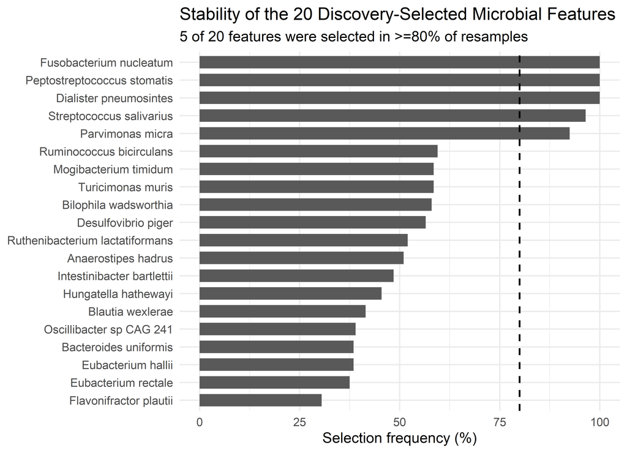

```r
# ==========================================================
# ORIGINAL 20 FEATURE STABILITY PLOT
# ==========================================================

plot_data <- original20_stability

# Extract species name for readable labels
plot_data$Species <- sub(
  ".*\\|s__",
  "",
  plot_data$Feature
)

plot_data$Species <- gsub(
  "_",
  " ",
  plot_data$Species
)

plot_data$Species <- factor(
  plot_data$Species,
  levels = plot_data$Species[
    order(
      plot_data$Selection_Percent
    )
  ]
)

stability_fig <- ggplot(
  plot_data,
  aes(
    x = Selection_Percent,
    y = Species
  )
) +

  geom_col(
    width = 0.70
  ) +

  geom_vline(
    xintercept = 80,
    linetype = "dashed",
    linewidth = 0.7
  ) +

  labs(
    title = "Stability of the 20 Discovery-Selected Microbial Features",
    subtitle = paste0(
      n_ge_80,
      " of 20 features were selected in >=80% of resamples"
    ),
    x = "Selection frequency (%)",
    y = NULL
  ) +

  coord_cartesian(
    xlim = c(0, 100)
  ) +

  theme_minimal(
    base_size = 12
  )

print(
  stability_fig
)
```

```r
stability_fig_path <- file.path(
  figures_dir,
  "Feature_Selection_Stability_Original_20.png"
)

ggsave(
  stability_fig_path,
  plot = stability_fig,
  width = 9,
  height = 7,
  dpi = 300
)

cat(
  "Saved:",
  stability_fig_path,
  "\n"
)
## Saved: C:/CRC/CRC_Quantum_Microbiome_Githb/CRC_Quantum_Microbiome_GitHub_RMD/02 Classical ML/figures/Feature_Selection_Stability_Original_20.png
```

# 11 11. Final Reproducibility Summary

```r
# ==========================================================
# FINAL REPRODUCIBILITY CHECK
# ==========================================================

final_checks <- c(

  "Shared 92-sample training set" =
    nrow(X_train_raw) == 92,

  "Exactly 20 original features" =
    length(original_features) == 20,

  "200 stability iterations completed" =
    length(selected_features_list) == 200,

  "Original 20 stability table created" =
    nrow(original20_stability) == 20,

  "All-feature stability table saved" =
    file.exists(stability_table_path),

  "Original-20 stability table saved" =
    file.exists(original20_path),

  "Iteration summary saved" =
    file.exists(iteration_summary_path),

  "Warning log saved" =
    file.exists(warning_log_path),

  "Stability figure saved" =
    file.exists(stability_fig_path)

)

print(
  final_checks
)
```

```
##       Shared 92-sample training set        Exactly 20 original features
##                                TRUE                                TRUE
##  200 stability iterations completed Original 20 stability table created
##                                TRUE                                TRUE
##   All-feature stability table saved   Original-20 stability table saved
##                                TRUE                                TRUE
##             Iteration summary saved                   Warning log saved
##                                TRUE                                TRUE
##              Stability figure saved
##                                TRUE
```

```r
cat(
  "\nAll checks passed:",
  all(final_checks),
  "\n"
)
```

```
##
## All checks passed: TRUE
```

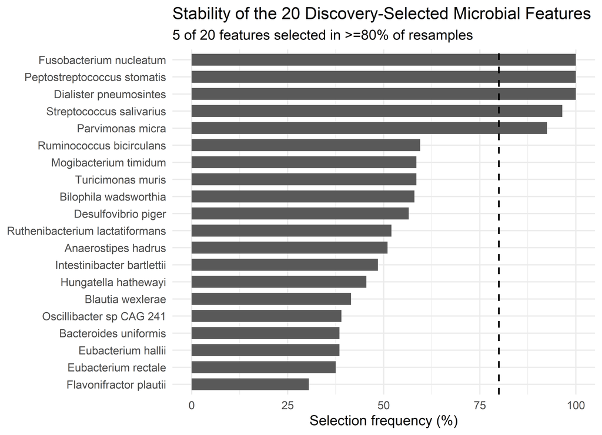

```r
# ==========================================================
# ORIGINAL 20 FEATURE STABILITY PLOT
# ==========================================================

plot_data <- original20_stability

plot_data$Species <- sub(
  ".*\\|s__",
  "",
  plot_data$Feature
)

plot_data$Species <- gsub(
  "_",
  " ",
  plot_data$Species
)

plot_data$Species <- factor(
  plot_data$Species,
  levels = plot_data$Species[
    order(plot_data$Selection_Percent)
  ]
)

stability_fig <- ggplot(
  plot_data,
  aes(
    x = Selection_Percent,
    y = Species
  )
) +
  geom_col(width = 0.70) +
  geom_vline(
    xintercept = 80,
    linetype = "dashed",
    linewidth = 0.7
  ) +
  labs(
    title = "Stability of the 20 Discovery-Selected Microbial Features",
    subtitle = paste0(
      n_ge_80,
      " of 20 features selected in >=80% of resamples"
    ),
    x = "Selection frequency (%)",
    y = NULL
  ) +
  coord_cartesian(xlim = c(0, 100)) +
  theme_minimal(base_size = 12)

print(stability_fig)
```

```r
stability_fig_path <- file.path(
  figures_dir,
  "Feature_Selection_Stability_Original_20.png"
)

ggsave(
  stability_fig_path,
  plot = stability_fig,
  width = 9,
  height = 7,
  dpi = 300
)

cat("Saved:", stability_fig_path, "\n")
## Saved: C:/CRC/CRC_Quantum_Microbiome_Githb/CRC_Quantum_Microbiome_GitHub_RMD/02 Classical ML/figures/Feature_Selection_Stability_Original_20.png
```

## 11.1 Session information

The final section records the exact R session used for this knit. The same information is also saved as a text artifact so the HTML report and repository contain both a human-readable and machine-readable provenance record.

```r
session_file <- file.path(
  results_dir,
  "session_info",
  "09_Feature_Selection_Stability_sessionInfo.txt"
)
cat("Saved session information to:", session_file, "\n\n")
## Saved session information to: C:/CRC/CRC_Quantum_Microbiome_Githb/CRC_Quantum_Microbiome_GitHub_RMD/02 Classical ML/results/session_info/09_Feature_Selection_Stability_sessionInfo.txt
```

[session information not shown]